# PEC1_JGuitart_GSE55662

Judith Guitart

10/4/2020

### A1. Identificación de las muestras y los grupos

Se ha escogido el estudio GSE55662 y se han descargado los datos y guardado en una carpeta en la asignatura con el nombre de ‘PEC1’. .

En este directorio vamos a crear carpetas para los análisis, los datos y los resultados.

```r
dir.create("MicroArrayAnalisis")
dir.create("Datos")
dir.create("Resultados")
```

Guardamos los archivos .CEL descargados de la base de datos ‘Gene Expression Omnibus’ (GEO) en la nueva carpeta ‘Datos’.

A continuación, pasamos a crear y leer el archivo *‘targets’*, que nos servirá para retener toda la información relevante para el análisis de los archivos .CEL individuales en un solo arhivo.

```r
targets.pec <- read.csv2("./Datos/targets.csv", header = TRUE, sep = ";")
knitr::kable(targets.pec, booktabs = TRUE, caption = "Contenido del archivo targets usado para este análisis")
```

Contenido del archivo targets usado para este análisis

| FileName | Group | Genotype | Treatment | ShortName |
| --- | --- | --- | --- | --- |
| GSM1341344_01_E_coli_2_ | WT_ntCPR | WT | Not-treated | wt_nt.1 |
| GSM1341345_02_E_coli_2_ | WT_ntCPR | WT | Not-treated | wt_nt.2 |
| GSM1341346_03_E_coli_2_ | WT_CPR | WT | CPR | wt_cpr.1 |
| GSM1341347_04_E_coli_2_ | WT_CPR | WT | CPR | wt_cpr.2 |
| GSM1341348_07_E_coli_2_ | FUR_ntCPR | fur | Not-treated | fur_nt.1 |
| GSM1341349_08_E_coli_2_ | FUR_ntCPR | fur | Not-treated | fur_nt.2 |
| GSM1341350_09_E_coli_2_ | FUR_CPR | fur | CPR | fur_cpr.1 |
| GSM1341351_10_E_coli_2_ | FUR_CPR | fur | CPR | fur_cpr.2 |

Finalmente, procedemos a leer los archivos .CEL con la función *list.celfiles* del paquete *oligo*:

```r
library(oligo)
archivosCEL <- list.celfiles("./Datos", full.names = TRUE)
```

A continuación, guardamos el archivo ‘tagets.csv’ generado anteriormente en una nueva variable para asociar la información de los archivos .CEL al mismo. Utilizamos la función *read.AnnotatedDataFrame* del paquete *Biobase*.

```r
library(Biobase)
mis.targets <- read.AnnotatedDataFrame(file.path("./Datos", "targets.csv"), header = TRUE, row.names = 1, sep=";")
rawData <- read.celfiles(archivosCEL, phenoData = mis.targets)
```

```
## Platform design info loaded.
```

```
## Reading in : ./Datos/GSM1341344_01_E_coli_2_.CEL
## Reading in : ./Datos/GSM1341345_02_E_coli_2_.CEL
## Reading in : ./Datos/GSM1341346_03_E_coli_2_.CEL
## Reading in : ./Datos/GSM1341347_04_E_coli_2_.CEL
## Reading in : ./Datos/GSM1341348_07_E_coli_2_.CEL
## Reading in : ./Datos/GSM1341349_08_E_coli_2_.CEL
## Reading in : ./Datos/GSM1341350_09_E_coli_2_.CEL
## Reading in : ./Datos/GSM1341351_10_E_coli_2_.CEL
```

Así, obtenemos el *ExpressionSet* y podemos cambiar el nombre largo de los archivos .CEL por el nombre corto establecido en el archivo ‘targets.csv’:

```r
mis.targets@data$ShortName -> rownames(pData(rawData))
colnames(rawData) <- rownames(pData(rawData))
head(rawData)
```

```
## ExpressionFeatureSet (storageMode: lockedEnvironment)
## assayData: 1 features, 8 samples
##   element names: exprs
## protocolData
##   rowNames: wt_nt.1 wt_nt.2 ... fur_cpr.2 (8 total)
##   varLabels: exprs dates
##   varMetadata: labelDescription channel
## phenoData
##   rowNames: wt_nt.1 wt_nt.2 ... fur_cpr.2 (8 total)
##   varLabels: Group Genotype Treatment ShortName
##   varMetadata: labelDescription channel
## featureData: none
## experimentData: use 'experimentData(object)'
## Annotation: pd.e.coli.2
```

Por lo tanto, de las 8 muestras, existen 4 grupos distintos con dos réplicas cada uno, en el siguiente orden: WT sin tratamiento, WT tratado con ciprofloxacina, -fur sin tratamiento, -fur tratado con ciprofloxacina.

### A2. Control de calidad de los datos crudos

Una vez hemos cargado los datos crudos con el nombre ‘rawData’ podemos pasar a determinar la calidad de estos datos antes de normalizar los datos.

```r
library(arrayQualityMetrics)
```

Podemos realizar este análisis también mediante un análisis de componentes principales.

```r
library(ggplot2)
library(ggrepel)
plotPCA3 <- function (datos, labels, factor, title, scale, colores, size = 1.5, glineas = 0.25) {
 data <- prcomp(t(datos),scale=scale)
 dataDf <- data.frame(data$x)
 Group <- factor
 loads <- round(data$sdev^2/sum(data$sdev^2)*100,1)
 p1 <- ggplot(dataDf,aes(x=PC1, y=PC2)) +
   theme_classic() +
   geom_hline(yintercept = 0, color = "gray70") +
   geom_vline(xintercept = 0, color = "gray70") +
   geom_point(aes(color = Group), alpha = 0.55, size = 3) +
   coord_cartesian(xlim = c(min(data$x[,1])-5,max(data$x[,1])+5)) +
   scale_fill_discrete(name = "Group")
 p1 + geom_text_repel(aes(y = PC2 + 0.25, label = labels),segment.size = 0.25, size = size) +
   labs(x = c(paste("PC1",loads[1],"%")),y=c(paste("PC2",loads[2],"%"))) +
   ggtitle(paste("Análisis de componentes principales para:",title,sep=" "))+
   theme(plot.title = element_text(hjust = 0.5)) +
   scale_color_manual(values=colores)
}
```

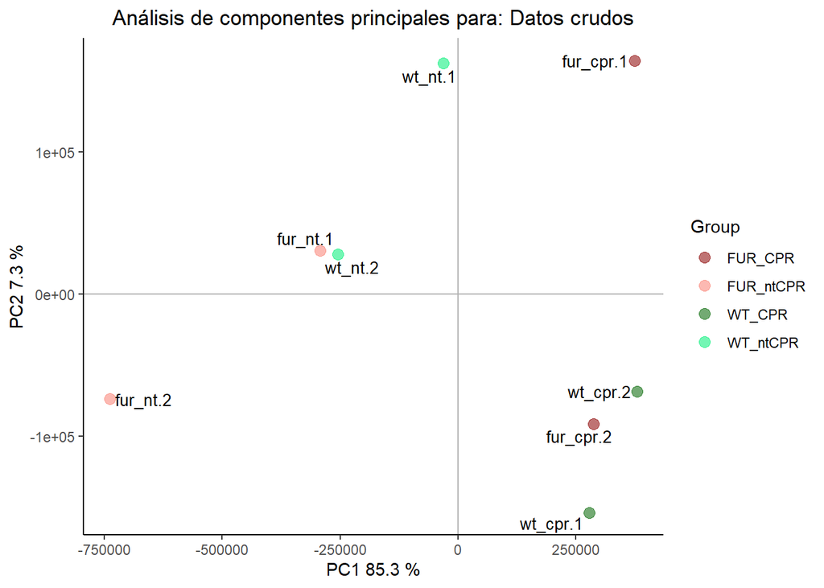

```r
plotPCA3(exprs(rawData), labels = targets.pec$ShortName, factor = targets.pec$Group,
        title="Datos crudos", scale = FALSE, size = 3.5,
        colores = c("darkred", "salmon", "darkgreen", "springgreen2"))
```

Cada color pertenece a cada uno de los cuatro grupos del estudio.

Observamos que el análisis de componentes principales cuenta con un 85.3% del total de la variabilidad de las muestras. Seguramente, esta variabilidad es contribuida principalmente por la condición del tratamiento, ya que observamos tanto la cepa salvaje como la mutante no tratadas a la izquierda y las tratadas con el antibiótico a la derecha.

Podemos guardar este gráfico en el formato *.tiff*, creando una nueva carpeta en el directorio que vamos a nombrar *‘Figuras’*:

```r
dir.create("Figuras")
tiff("./Figuras/PCA_RawData.tiff", res = 200, width = 4.5, height = 4, units = 'in')
plotPCA3(exprs(rawData), labels = targets.pec$ShortName, factor = targets.pec$Group,
        title="Raw data", scale = FALSE, size = 2,
        colores = c("darkred", "salmon", "darkgreen", "springgreen2"))
dev.off()
```

También podemos visualizar la distribución de la intensidad de los *arrays* con diagramas de cajas:

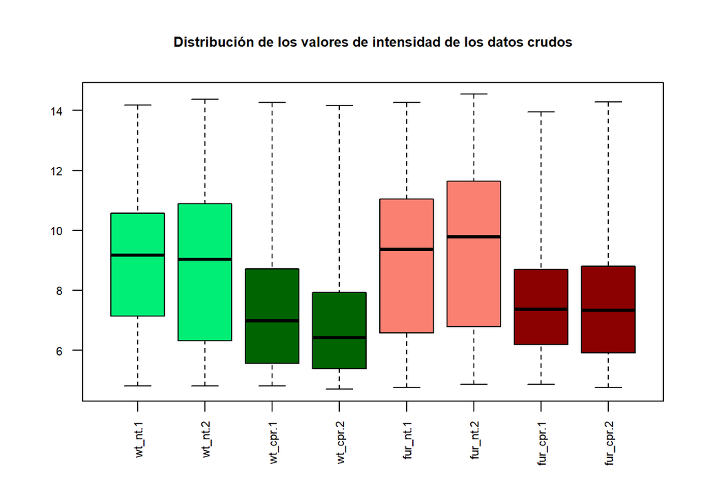

```r
boxplot(rawData, cex.axis=0.7, las=2, which="all", col = c(rep("springgreen2", 2), rep("darkgreen", 2), rep("salmon", 2), rep("darkred", 2)), main = "Distribución de los valores de intensidad de los datos crudos", cex.main = 0.8)
```

Se observa una gran variabilidad en la intensidad de los arrays, lo que ya es esperable en los datos crudos.

**Opcional**: Exploración y visualización

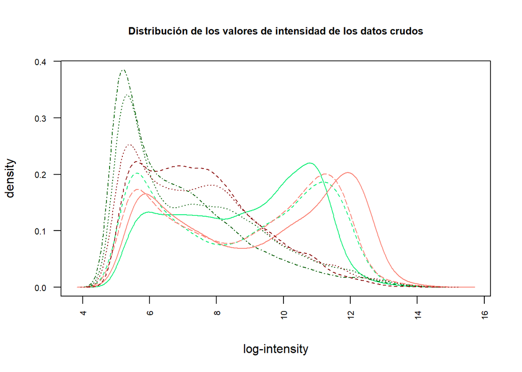

```r
hist(rawData, cex.axis=0.7, las=2, which="all", col = c(rep("springgreen2", 2), rep("darkgreen", 2), rep("salmon", 2), rep("darkred", 2)), main = "Distribución de los valores de intensidad de los datos crudos", cex.main = 0.8)
```

### 3. Normalización

Para hacer los arrays comparables entre ellos y así, reducir al máximo la variabilidad en las muestras que no es debida a razones biológicas, realizaremos un proceso de normalización. Refleja la expresión diferencial de los genes, que no es debida a efectos técnicos. Consiste de tres pasos: corrección del ruido de fondo o *background*, normalización y sumarización.

```r
eset_rma.pec <- rma(rawData)
```

```
## Background correcting
## Normalizing
## Calculating Expression
```

Implica una normalización por cuantiles que fuerza la homogeneidad de los arrays.

### 4. Control de calidad de los datos normalizados

Para saber como después de este proceso se observa la calidad de los datos, realizaremos un nuevo control de los mismos:

```r
arrayQualityMetrics(eset_rma.pec, outdir = file.path("./Resultados", "QCDir.Norm"), force = TRUE)
```

```
## The report will be written into directory './Resultados/QCDir.Norm'.
```

```
## (loaded the KernSmooth namespace)
```

Realizamos también PCA de los datos normalizados:

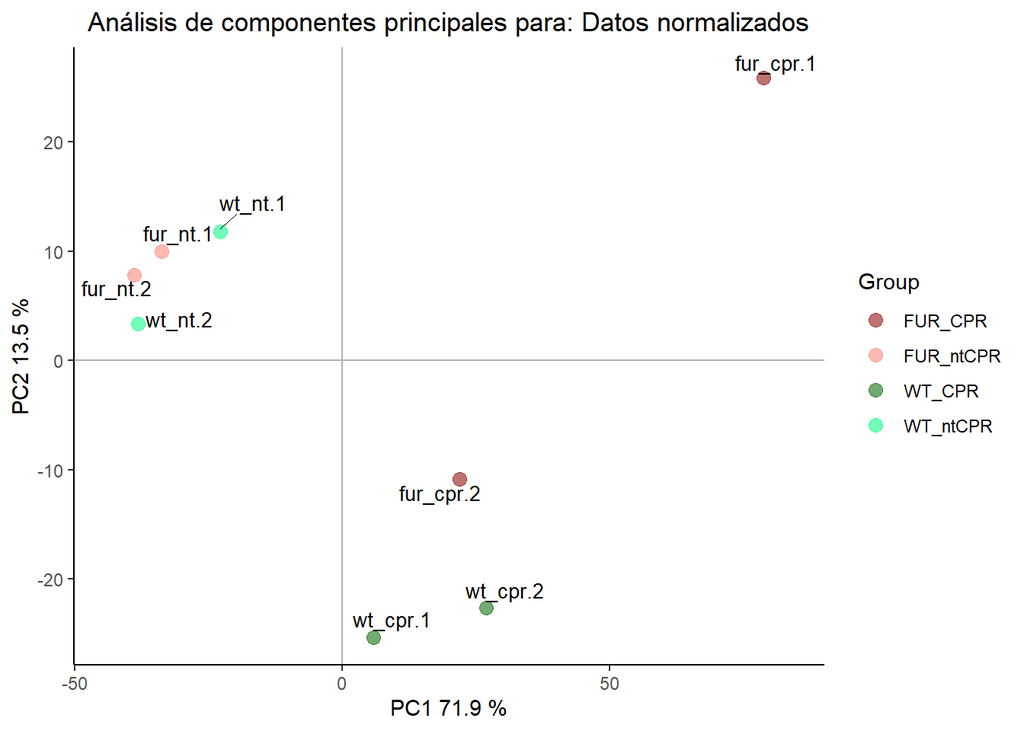

```r
plotPCA3(exprs(eset_rma.pec), labels = targets.pec$ShortName, factor = targets.pec$Group,
        title="Datos normalizados", scale = FALSE, size = 3.5,
        colores = c("darkred", "salmon", "darkgreen", "springgreen"))
```

Seguimos viendo la separación de ambos grupos y ahora también la aglomeración de los dos grupos no tratados en un mismo componente.

Ahora cuenta con un 71.9% de la variabilidad total. Es importante destacar una de las muestras que se encuentra lejos de la otra réplica, lo que puede ser debido a algun outlier.

Ahora podemos también observar la distribución de las intensidades con los datos normalizados, que en este caso, las cajas del diagrama se espera que sean muy similares.

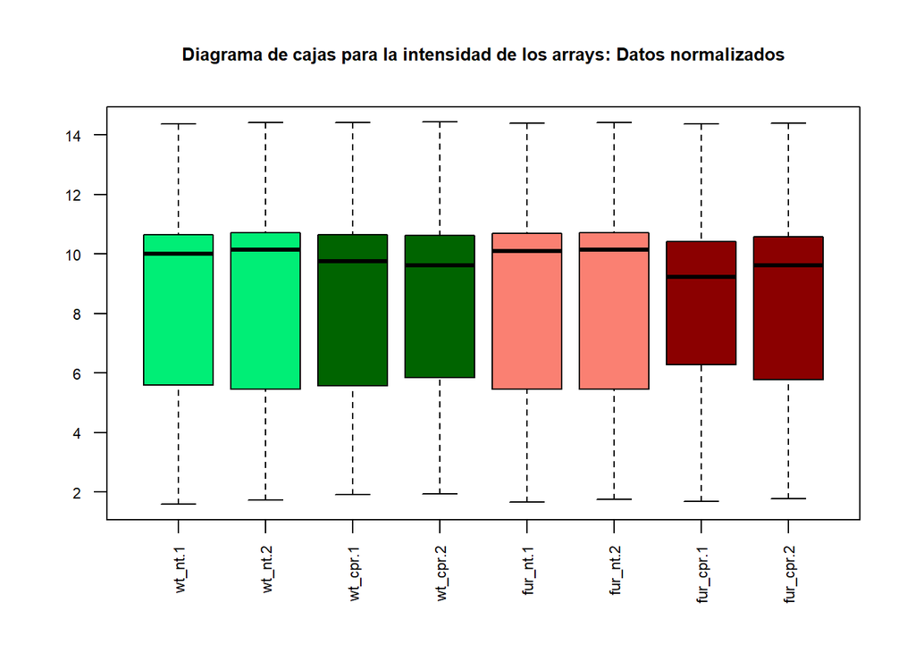

```r
boxplot(eset_rma.pec, cex.axis=0.7, las=2,  which="all",
        col = c(rep("springgreen2", 2), rep("darkgreen", 2), rep("salmon", 2), rep("darkred", 2)),
        main="Diagrama de cajas para la intensidad de los arrays: Datos normalizados", cex.main = 0.8)
```

Ahora podemos observar que las intensidades de los arrays son mucho más parecidas.

Para identificar y eliminar los efectos de los distintos lotes, realizaremos un Análisis de componente de variación combate y principal (PVCA):

```r
library(pvca)
pData(eset_rma.pec) <- targets.pec
pct_threshold <- 0.6
batch.factors <- c("Genotype", "Treatment")
pvcaObj <- pvcaBatchAssess(eset_rma.pec, batch.factors, pct_threshold)
```

```
## boundary (singular) fit: see ?isSingular
## boundary (singular) fit: see ?isSingular
## boundary (singular) fit: see ?isSingular
```

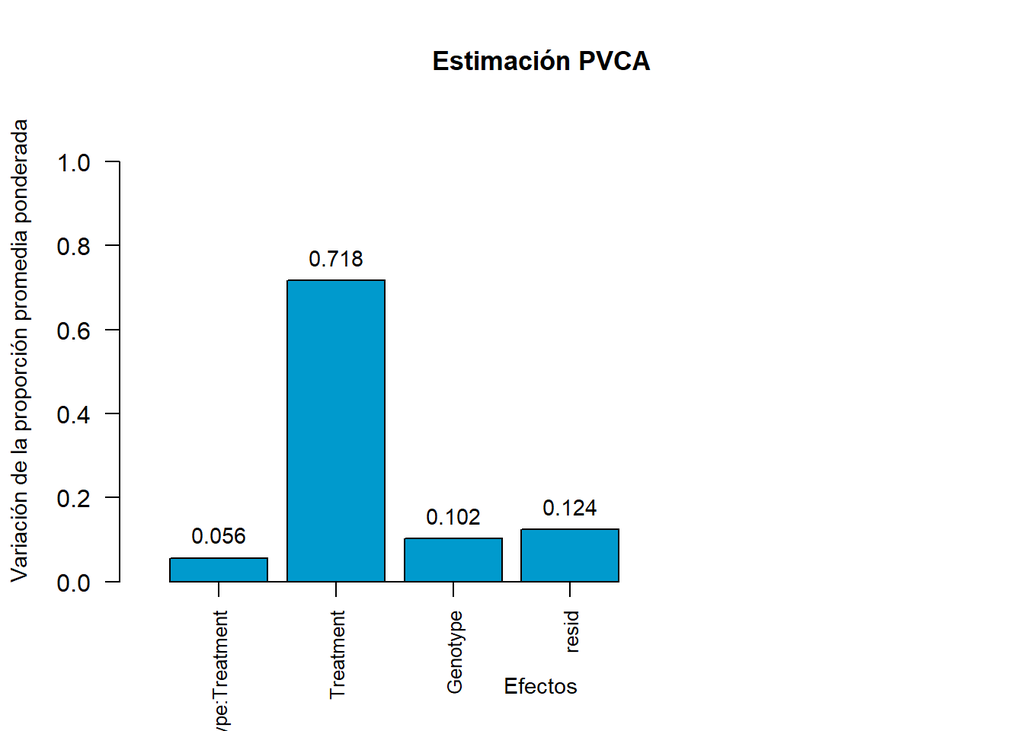

```r
bp <- barplot(pvcaObj$dat, xlab = "Efectos", ylab = "Variación de la proporción promedia ponderada", ylim = c(0,1.1), col=c("deepskyblue3"), las=2, main="Estimación PVCA", xlim = c(0,8), cex.main = 1.1, cex.lab = 0.9)
axis(1, at = bp, labels = pvcaObj$label, cex.axis = 0.8, las=2)
values = pvcaObj$dat
new_values = round(values, 3)
text(bp, pvcaObj$dat, labels = new_values, pos =3, cex = 0.9)
```

Este gráfico muestra que la mayor fuente de variación es la condición de tratamiento, lo que ya observamos previamente en los análisis de PCA.

### A5. Filtraje no específico

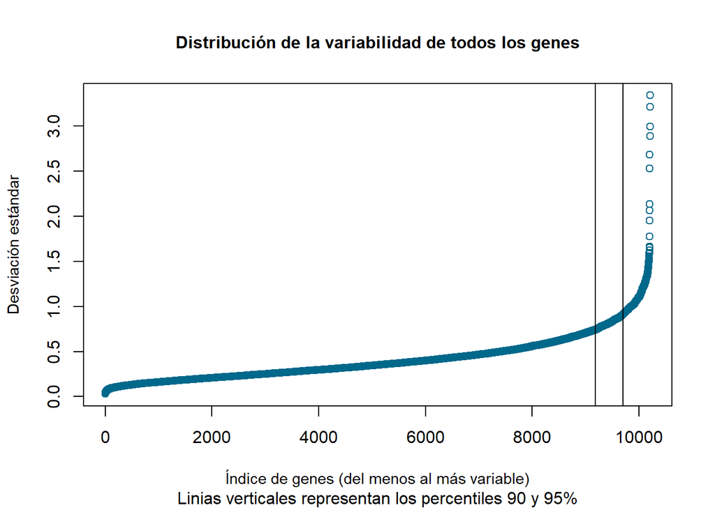

```r
sds <- apply(exprs(eset_rma.pec), 1, sd)
sds0 <- sort(sds)
plot(1:length(sds0), sds0, main="Distribución de la variabilidad de todos los genes", sub="Linias verticales representan los percentiles 90 y 95%", xlab= "Índice de genes (del menos al más variable)", ylab="Desviación estándar", col ="deepskyblue4", cex.main = 1, cex.lab = 0.9)
abline(v=length(sds)*c(0.9,0.95))
```

Filtraje de los genes menos variables, aquellos que pueden atribuirse a variabilidad aleatoria, que no se consideran diferencialmente expresados, lo que permite reducir el nombre de tests, incrementando así la potencia.

Basándonos en un lindar de variabilidad podemos eliminar estos genes con la función *nsFilter* del paquete *genefitler*: Permite eliminar los genes que varían poco entre condiciones o que deseamos quitar por otras razones, con la función *nsFilter*. Escogemos el lindar 0.5 default.

```r
library(genefilter)
BiocManager::install("ecoli2.db")
BiocManager::install("AnnotationDbi")
BiocManager::install("org.EcK12.eg.db")
library(ecoli2.db)
annotation(eset_rma.pec) <- "ecoli2.db"
filtered.pec <- nsFilter(eset_rma.pec, require.entrez = TRUE, remove.dupEntrez = TRUE, var.filter = TRUE, var.func = IQR, var.cutoff = 0.5, filterByQuantile = TRUE, feature.exclude = "^AFFX")
print(filtered.pec$filter.log)
```

```
## $numDupsRemoved
## [1] 179
##
## $numLowVar
## [1] 2066
##
## $numRemoved.ENTREZID
## [1] 5897
```

```r
eset_filtered.pec <- filtered.pec$eset
eset_filtered.pec
```

```
## ExpressionSet (storageMode: lockedEnvironment)
## assayData: 2066 features, 8 samples
##   element names: exprs
## protocolData
##   rowNames: wt_nt.1 wt_nt.2 ... fur_cpr.2 (8 total)
##   varLabels: exprs dates
##   varMetadata: labelDescription channel
## phenoData
##   rowNames: 1 2 ... 8 (8 total)
##   varLabels: FileName Group ... ShortName (5 total)
##   varMetadata: labelDescription channel
## featureData: none
## experimentData: use 'experimentData(object)'
## Annotation: ecoli2.db
```

Después del filtraje observamos que nos quedamos con 2066 genes y que hemos guardado estos en la variable *eset_filtered.pec*.

Procedemos a guardar los datos normalizados y filtrados:

```r
write.csv(exprs(eset_rma.pec), file="./Resultados/Datos.normalizados.csv")
write.csv(exprs(eset_filtered.pec), file="./Resultados/Datos.normalizados.filtrados.csv")
save(eset_rma.pec, eset_filtered.pec, file="./Resultados/Datos.normalizados.Rda")
```

### A6. Identificación de genes diferencialmente expresados

Ahora podemos proceder a generar la matriz de diseño para seleccionar los genes diferencialmente expresados para compara la expresión génica entre grupos. Usaremos el modelo de Smyth del paquete *limma*, como se ha estudiado en los recursos de la asignatura.

**La matriz de diseño es una tabla que describe cada muestra a un grupo o condición experimental:**

```r
if(!exists("eset_filtered.pec")) load(file="./Resultados/Datos.normalizados.Rda")
```

```r
library(limma)
Matdesign <- model.matrix(~0+Group, pData(eset_filtered.pec))
colnames(Matdesign) <- c("WT_ntCPR", "WT_CPR", "FUR_ntCPR", "FUR_CPR")
print(Matdesign)
```

```
##   WT_ntCPR WT_CPR FUR_ntCPR FUR_CPR
## 1        0      0         0       1
## 2        0      0         0       1
## 3        0      0         1       0
## 4        0      0         1       0
## 5        0      1         0       0
## 6        0      1         0       0
## 7        1      0         0       0
## 8        1      0         0       0
## attr(,"assign")
## [1] 1 1 1 1
## attr(,"contrasts")
## attr(,"contrasts")$Group
## [1] "contr.treatment"
```

**La matriz de contrastes permite realizar comparaciones entre los parámetros del modelo.**

(Preguntas de estudio)

1. Efectos del tratamiento en la cepa salvaje.
2. Efectos de la deleción del gen fur.
3. Efectos del tratamiento entre la cepa salvaje y la cepa mutante.

```r
Matcontrast <- makeContrasts(nt.WTvsFUR=FUR_ntCPR-WT_ntCPR, WT.ntvsCPR=WT_CPR-WT_ntCPR, FUR.ntvsCPR=FUR_CPR-FUR_ntCPR, levels = Matdesign)
print(Matcontrast)
```

```
##            Contrasts
## Levels      nt.WTvsFUR WT.ntvsCPR FUR.ntvsCPR
##   WT_ntCPR          -1         -1           0
##   WT_CPR             0          1           0
##   FUR_ntCPR          1          0          -1
##   FUR_CPR            0          0           1
```

**Estimación del modelo y selección de genes:**

Ahora podemos proceder a estimar el modelo y los contrastes y generar los test de significancia para determinar si los genes estan diferencialmente expresados o no.

El paquete *limma* utiliza los modelos de Bayes empíricos determinados como fold-change, aunque para controlar el porcentaje de falsos positivos, podemos ajustar los p-valores utilizando el método de Benjamini y Hochberg.

```r
library(limma)
fit.pec <- lmFit(eset_filtered.pec, Matdesign)
fit.main.pec <- contrasts.fit(fit.pec, Matcontrast)
fit.main.pec <- eBayes(fit.main.pec)
class(fit.main.pec)
```

```
## [1] "MArrayLM"
## attr(,"package")
## [1] "limma"
```

Ahora ya podemos obtener las listas de los genes diferencialmente expresados con la función *topTable* ordenados por el p-value.

```r
tt_nt.WTvsFUR <- topTable(fit.main.pec, number=nrow(fit.main.pec), coef = "nt.WTvsFUR", adjust = "fdr")
head(tt_nt.WTvsFUR)
```

```
##                  logFC   AveExpr         t      P.Value    adj.P.Val        B
## 1766589_s_at -1.783351 11.493399 -16.22278 6.155247e-07 0.0005031329 6.860600
## 1767506_s_at -1.967892 11.125541 -15.84490 7.264911e-07 0.0005031329 6.711526
## 1759831_at   -2.530968 12.090743 -15.83223 7.305899e-07 0.0005031329 6.706442
## 1765071_s_at  5.925855  9.012632  14.61249 1.281955e-06 0.0005754665 6.190534
## 1765838_s_at -1.839593 11.851474 -14.44043 1.392707e-06 0.0005754665 6.113259
## 1762671_s_at -1.771619 11.175903 -13.70120 2.010004e-06 0.0006921115 5.767503
```

```r
library(xlsx)
write.xlsx(tt_nt.WTvsFUR, file = "tt_nt.WTvsFUR.xlsx")
```

```r
tt_WT.ntvsCPR <- topTable(fit.main.pec, number=nrow(fit.main.pec), coef = "WT.ntvsCPR", adjust = "fdr")
head(tt_WT.ntvsCPR)
```

```
##                  logFC   AveExpr         t      P.Value    adj.P.Val        B
## 1764904_s_at -2.478467 12.129216 -17.56172 3.519295e-07 0.0006118159 7.309760
## 1764659_s_at -1.745830 11.663741 -15.51783 8.411388e-07 0.0006118159 6.550895
## 1763947_s_at -1.990319 11.623403 -15.39744 8.884065e-07 0.0006118159 6.501913
## 1767285_s_at -2.086288 11.943222 -14.41766 1.408159e-06 0.0006396866 6.083315
## 1761763_s_at -1.924742 12.104443 -14.22351 1.548128e-06 0.0006396866 5.995927
## 1763792_at    1.571757  9.334934  12.33891 4.159624e-06 0.0010005909 5.061069
```

```r
write.xlsx(tt_WT.ntvsCPR, file = "tt_WT.ntvsCPR.xlsx")
```

```r
tt_FUR.ntvsCPR <- topTable(fit.main.pec, number=nrow(fit.main.pec), coef="FUR.ntvsCPR", adjust = "fdr")
head(tt_FUR.ntvsCPR)
```

```
##                  logFC  AveExpr         t      P.Value    adj.P.Val        B
## 1764904_s_at -2.544557 12.12922 -18.03002 2.922195e-07 0.0004641344 7.498647
## 1763947_s_at -2.105803 11.62340 -16.29084 5.976549e-07 0.0004641344 6.877074
## 1761763_s_at -2.167163 12.10444 -16.01496 6.739609e-07 0.0004641344 6.769956
## 1764659_s_at -1.662496 11.66374 -14.77711 1.185259e-06 0.0006121863 6.256939
## 1766450_s_at -1.483903 11.05486 -12.75760 3.301221e-06 0.0009813559 5.289097
## 1760213_s_at -1.705236 10.48187 -12.73879 3.335180e-06 0.0009813559 5.279211
```

```r
write.xlsx(tt_FUR.ntvsCPR, file = "tt_FUR.ntvsCPR.xlsx")
```

La primera columna de cada tabla contiene el ID del array de Affymetrix que cada probeset.

### A7. Anotación de los resultados

Permite asociar los identificadores del apartado anterior con identificadores con nombres familiares, por ejemplo con el Gene Symbol. Creamos una función para facilitar la generación de estas tablas de anotaciones.

```r
annotatedTopTable <- function(topTab, anotPackage)
{
 topTab <- cbind(PROBEID=rownames(topTab), topTab)
 myProbes <- rownames(topTab)
 thePackage <- eval(parse(text = anotPackage))
 geneAnots <- select(thePackage, myProbes, c("SYMBOL", "ENTREZID", "GENENAME"))
 annotatedTopTab<- merge(x=geneAnots, y=topTab, by.x="PROBEID", by.y="PROBEID")
return(annotatedTopTab)
}
```

```r
topAnotados_nt.WTvsFUR <- annotatedTopTable(tt_nt.WTvsFUR, anotPackage = "ecoli2.db")
topAnotados_WT.ntvsCPR <- annotatedTopTable(tt_WT.ntvsCPR, anotPackage = "ecoli2.db")
topAnotados_FUR.ntvsCPR <- annotatedTopTable(tt_FUR.ntvsCPR, anotPackage = "ecoli2.db")
write.csv(topAnotados_WT.ntvsCPR, file="./Resultados/topAnotados_WT.ntvsCPR.csv")
write.csv(topAnotados_nt.WTvsFUR, file="./Resultados/topAnotados_nt.WTvsFUR.csv")
write.csv(topAnotados_FUR.ntvsCPR, file="./Resultados/topAnotados_FUR.ntvsCPR.csv")
```

### A8. Comparación entre distintas comparaciones

```r
library(limma)
res.pec <- decideTests(fit.main.pec, method ="separate", adjust.method = "fdr", p.value = 0.1, lfc = 1)
```

Tabla de anotaciones sencilla:

```r
sum.res.rows.pec <- apply(abs(res.pec),1,sum)
res.selected.pec <- res.pec[sum.res.rows.pec!=0,]
print(summary(res.pec))
```

```
##        nt.WTvsFUR WT.ntvsCPR FUR.ntvsCPR
## Down           42         70         141
## NotSig       2012       1572        1778
## Up             12        424         147
```

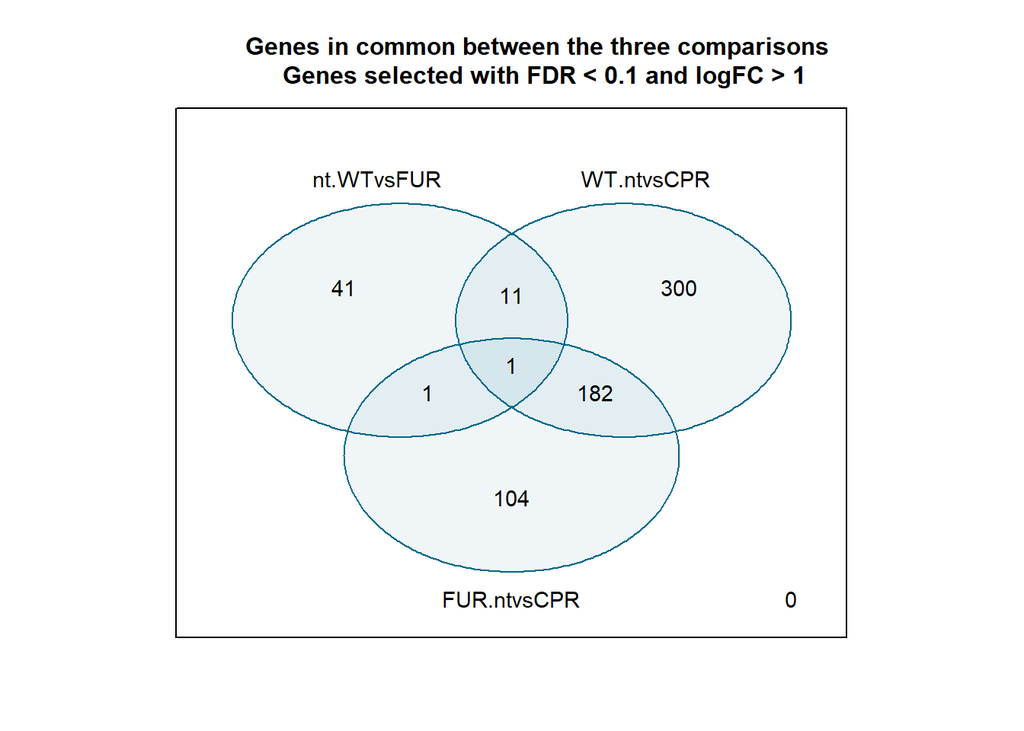

```r
vennDiagram(res.selected.pec[,1:3], cex = 0.9, circle.col = "deepskyblue4")
title("Genes in common between the three comparisons \n Genes selected with FDR < 0.1 and logFC > 1", cex.main = 1)
```

### A9. Visualización de la expresión diferencial con volcano plots

Nos permiten observar si hay muchos o pocos genes con elevado cambio en la expresión y la significación de la expresión.

```r
library(ecoli2.db)
geneSymbols <- select(ecoli2.db, rownames(fit.main.pec), c("SYMBOL"))
```

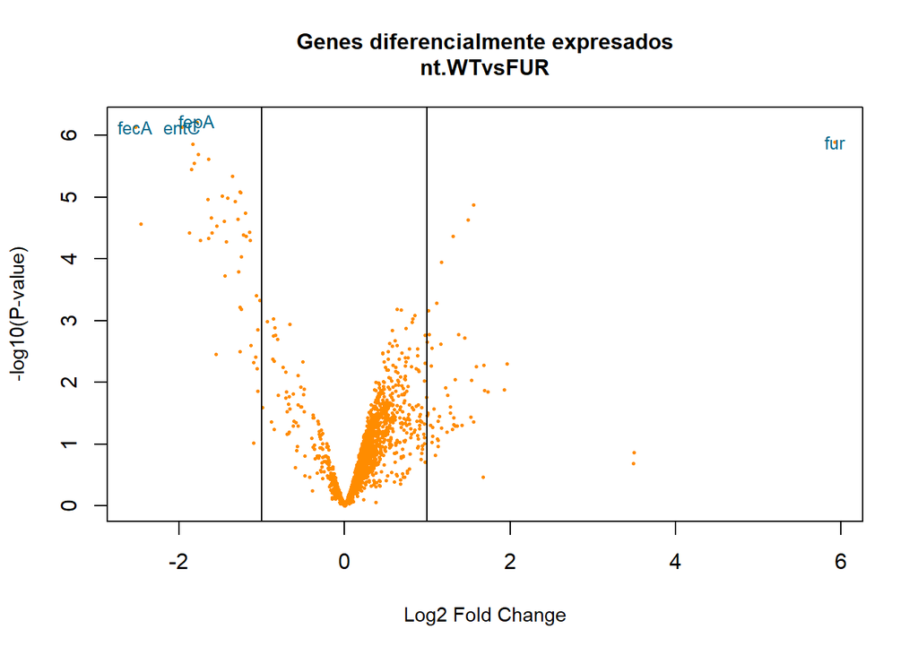

```r
SYMBOLS <- geneSymbols$SYMBOL
volcanoplot(fit.main.pec, coef=1, highlight=4, names=SYMBOLS, main=paste("Genes diferencialmente expresados", colnames(Matcontrast)[1], sep="\n"), hl.col="deepskyblue4", col=c("darkorange"), cex.main = 1, cex.lab = 0.9)
abline(v=c(-1,1))
```

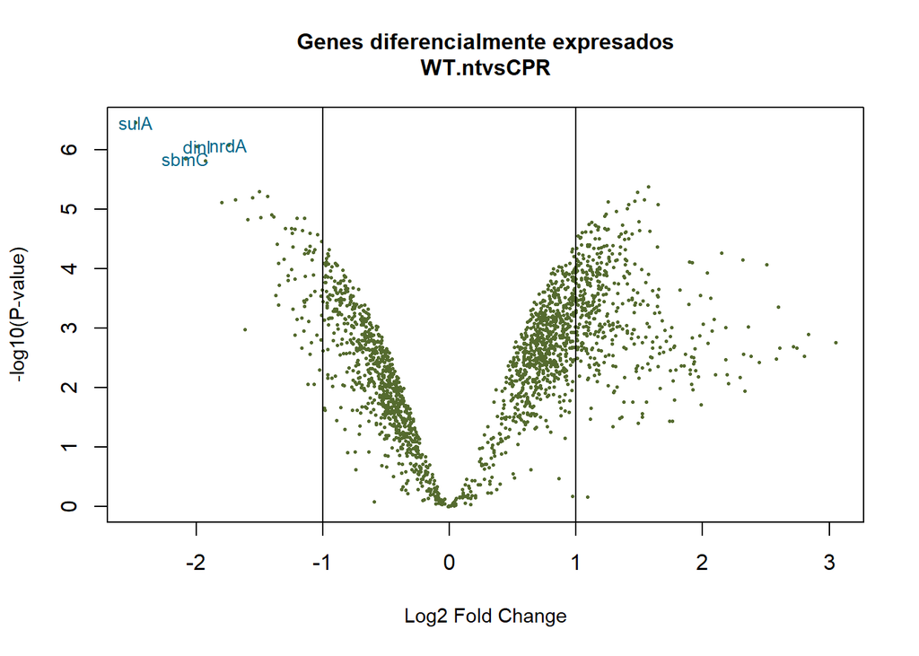

```r
volcanoplot(fit.main.pec, coef=2, highlight=4, names=SYMBOLS, main=paste("Genes diferencialmente expresados", colnames(Matcontrast)[2], sep="\n"), hl.col="deepskyblue4", col=c("darkolivegreen"), cex.main = 1, cex.lab = 0.9)
abline(v=c(-1,1))
```

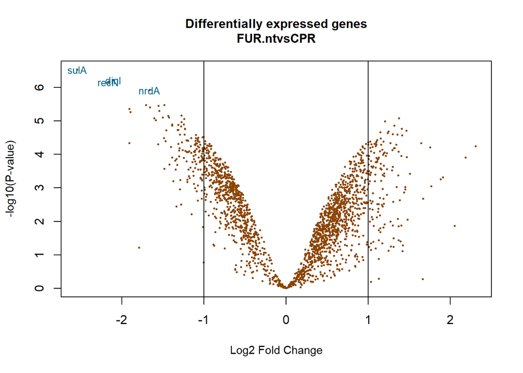

```r
volcanoplot(fit.main.pec, coef=3, highlight=4, names=SYMBOLS, main=paste("Differentially expressed genes", colnames(Matcontrast)[3], sep="\n"), hl.col="deepskyblue4", col=c("darkorange4"), cex.main = 1, cex.lab = 0.9)
abline(v=c(-1,1))
```

**Heatmaps:**

```r
probesInHeatmap.pec <- rownames(res.selected.pec)
DatosHM <- exprs(eset_filtered.pec)[rownames(exprs(eset_filtered.pec)) %in% probesInHeatmap.pec,]

geneSymbols <- select(ecoli2.db, rownames(DatosHM), c("SYMBOL"))
SYMBOLS<- geneSymbols$SYMBOL
rownames(DatosHM) <- SYMBOLS
write.csv(DatosHM, file = file.path("./Resultados/DatosHM.csv"))
```

Primero sin dendograma

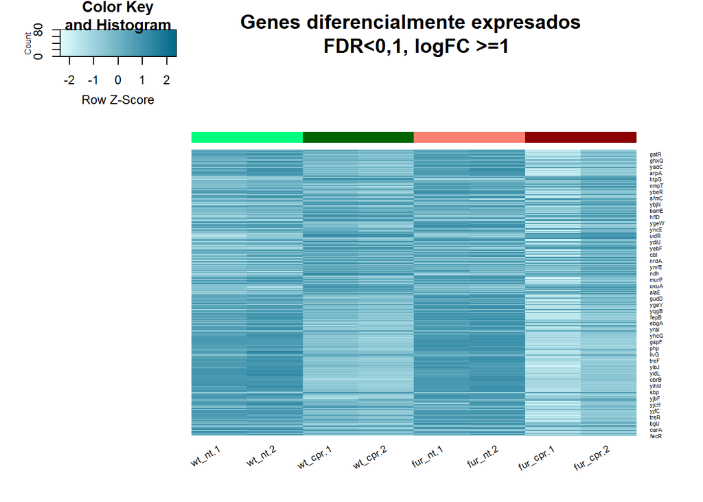

```r
my_palette <- colorRampPalette(c("lightcyan", "deepskyblue4"))(n = 299)
library(gplots)
heatmap.2(DatosHM,
        Rowv = FALSE,
        Colv = FALSE,
        main = "Genes diferencialmente expresados \n FDR<0,1, logFC >=1",
        scale = "row",
        col = my_palette,
        sepcolor = "white",
        sepwidth = c(0.05,0.05),
        cexRow = 0.5,
        cexCol = 0.9,
        key = TRUE,
        keysize = 1.5,
        density.info = "histogram",
        ColSideColors = c(rep("springgreen",2),rep("darkgreen",2), rep("salmon",2), rep("darkred",2)),
        tracecol = NULL,
        dendrogram = "none",
        srtCol = 30)
```

Agrupando genes y muestras por su similaridad:

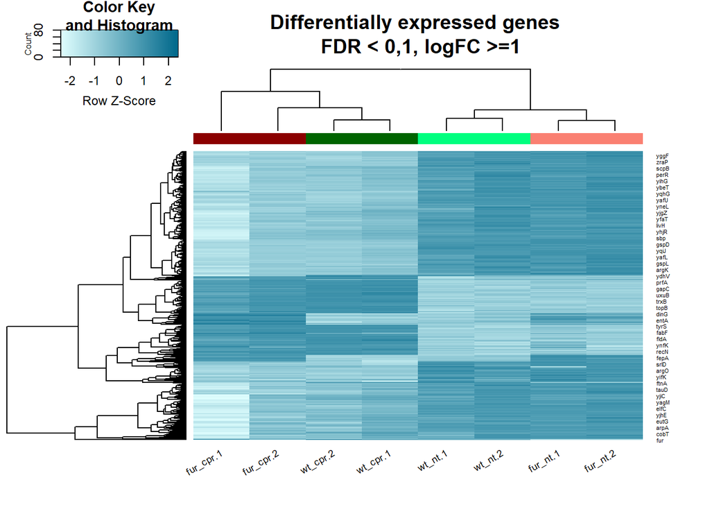

```r
heatmap.2(DatosHM,
         Rowv = TRUE,
         Colv = TRUE,
         dendrogram = "both",
         main = "Differentially expressed genes \n FDR < 0,1, logFC >=1", cex.main = 0.8,
         scale = "row",
         col = my_palette,
         sepcolor = "white",
         sepwidth = c(0.05,0.05),
         cexRow = 0.5,
         cexCol = 0.9,
         key = TRUE,
         keysize = 1.5,
         density.info = "histogram",
         ColSideColors = c(rep("springgreen",2),rep("darkgreen",2), rep("salmon",2), rep("darkred",2)),
         tracecol = NULL,
         srtCol = 30)
```

```r
png("heatmap.png")
heatmap.2(DatosHM,
         Rowv = TRUE,
         Colv = TRUE,
         dendrogram = "both",
         main = "Differentially expressed genes \n FDR < 0,1, logFC >=1", cex.main = 0.8,
         scale = "row",
         col = my_palette,
         sepcolor = "white",
         sepwidth = c(0.05,0.05),
         cexRow = 0.5,
         cexCol = 0.9,
         key = TRUE,
         keysize = 1.5,
         density.info = "histogram",
         ColSideColors = c(rep("springgreen",2),rep("darkgreen",2), rep("salmon",2), rep("darkred",2)),
         tracecol = NULL,
         srtCol = 30)
dev.off()
```

### A10. Análisis de significación biológica (“Gene enrichment analysis”)

```r
ListaTablas.pec <- list(nt.WTvsFUR  = tt_nt.WTvsFUR, WT.ntvsCPR = tt_WT.ntvsCPR, FUR.ntvsCPR = tt_FUR.ntvsCPR)
ListaSeleccionados.pec <- list()
for (i in 1:length(ListaTablas.pec)){
 # select the toptable
 topTab <- ListaTablas.pec[[i]]
 # select the genes to be included in the analysis
 whichGenes<-topTab["adj.P.Val"]<0.15
 selectedIDs <- rownames(topTab)[whichGenes]
 # convert the ID to Entrez
 EntrezIDs<- select(ecoli2.db, selectedIDs, c("ENTREZID"))
 EntrezIDs <- EntrezIDs$ENTREZID
 ListaSeleccionados.pec[[i]] <- EntrezIDs
 names(ListaSeleccionados.pec)[i] <- names(ListaTablas.pec)[i]
}
sapply(ListaSeleccionados.pec, length)
```

```
##  nt.WTvsFUR  WT.ntvsCPR FUR.ntvsCPR
##         115        1893        1753
```

Como es E. coli no podemos utilizar el package Reactome PA, utilizaremos la función enrichGO del paquete *clusterProfiler*.

```r
BiocManager::install("AnnotationDbi")
BiocManager::install("clusterProfiler")
library(AnnotationDbi)
library(clusterProfiler)
```

```r
library(igraph)
ListaDatos.pec <- ListaSeleccionados.pec[1:3]
comparisonsNames <- names(ListaDatos.pec)

for (i in 1:length(ListaDatos.pec)){
 genesIn <- ListaDatos.pec[[i]]
 comparison <- comparisonsNames[i]
 enrich.result <- enrichGO(gene = genesIn, OrgDb = "org.EcK12.eg.db", ont = "ALL", pAdjustMethod ="BH", pvalueCutoff = 0.05, readable = TRUE)

 cat("##################################")
 cat("\nComparison: ", comparison,"\n")
 print(head(enrich.result))

 if (length(rownames(enrich.result@result)) != 0) {
 write.csv(as.data.frame(enrich.result),
            file =paste0("./Resultados/","Enrich.Results.",comparison,".csv"),
            row.names = FALSE)
 write.xlsx(as.data.frame(enrich.result),
            file =paste0("./Resultados/","Enrich.Results.",comparison,".xlsx"),
            row.names = FALSE)

 pdf(file=paste0("./Resultados/","Enrich.Barplot.",comparison,".pdf"))
   print(barplot(enrich.result, showCategory = 15, font.size = 6,
           title = paste0("EnrichGO Pathway Analysis for ", comparison,". Barplot")))
 dev.off()

 pdf(file = paste0("./Resultados/","EnrichGOcnetplot.",comparison,".pdf"))
   print(cnetplot(enrich.result, categorySize = "geneNum", schowCategory = 15,
        vertex.label.cex = 0.75))
 dev.off()

 }
}
```

```
## ##################################
## Comparison:  nt.WTvsFUR
##            ONTOLOGY         ID                                    Description
## GO:0009237       BP GO:0009237                  siderophore metabolic process
## GO:0009712       BP GO:0009712 catechol-containing compound metabolic process
## GO:0018958       BP GO:0018958   phenol-containing compound metabolic process
## GO:0019184       BP GO:0019184      nonribosomal peptide biosynthetic process
## GO:0006826       BP GO:0006826                             iron ion transport
## GO:0044550       BP GO:0044550      secondary metabolite biosynthetic process
##            GeneRatio BgRatio       pvalue     p.adjust       qvalue
## GO:0009237     10/82 10/2754 3.144096e-16 9.935344e-14 8.505608e-14
## GO:0009712      9/82 10/2754 1.153969e-13 1.823272e-11 1.560896e-11
## GO:0018958      9/82 11/2754 6.194912e-13 4.893980e-11 4.189717e-11
## GO:0019184      9/82 11/2754 6.194912e-13 4.893980e-11 4.189717e-11
## GO:0006826     11/82 20/2754 1.116166e-12 7.054170e-11 6.039047e-11
## GO:0044550      9/82 12/2754 2.418646e-12 1.273820e-10 1.090512e-10
##                                                            geneID Count
## GO:0009237        entC/fur/ybdZ/entB/fes/entE/entA/entF/entH/entD    10
## GO:0009712            entC/ybdZ/entB/fes/entE/entA/entF/entH/entD     9
## GO:0018958            entC/ybdZ/entB/fes/entE/entA/entF/entH/entD     9
## GO:0019184            entC/fur/ybdZ/entB/entE/entA/entF/entH/entD     9
## GO:0006826 fepA/fecA/feoA/exbB/feoB/yoeA/fepB/fepG/fepD/fepE/cirA    11
## GO:0044550            entC/fur/ybdZ/entB/entE/entA/entF/entH/entD     9
```

[output not shown]

```
## ##################################
## Comparison:  FUR.ntvsCPR
##            ONTOLOGY         ID                           Description GeneRatio
## GO:0009432       BP GO:0009432                          SOS response   19/1136
## GO:0045184       BP GO:0045184 establishment of protein localization   27/1136
## GO:0006886       BP GO:0006886       intracellular protein transport   12/1136
## GO:0034613       BP GO:0034613         cellular protein localization   20/1136
## GO:0070727       BP GO:0070727   cellular macromolecule localization   20/1136
## GO:0008104       BP GO:0008104                  protein localization   29/1136
##            BgRatio       pvalue   p.adjust     qvalue
## GO:0009432 22/2754 1.595970e-05 0.01281564 0.01246537
## GO:0045184 37/2754 8.390117e-05 0.03042732 0.02959569
## GO:0006886 13/2754 1.894702e-04 0.03042732 0.02959569
## GO:0034613 26/2754 2.237408e-04 0.03042732 0.02959569
## GO:0070727 26/2754 2.237408e-04 0.03042732 0.02959569
## GO:0008104 42/2754 2.273523e-04 0.03042732 0.02959569
##                                                                                                                                                    geneID
## GO:0009432                                                   sulA/dinI/recN/ruvA/dinG/recA/yebG/umuD/cho/polB/ruvB/rimK/dinB/umuC/lexA/recX/dinD/uvrD/ssb
## GO:0045184           napD/ffh/secA/secD/bamE/gspJ/gspI/gspF/gspE/lolA/tatC/bamB/tatE/tolA/tatB/secE/ftsY/secY/yhjG/yidC/secG/asmA/hofC/tatA/bamA/csgE/skp
## GO:0006886                                                                                     ffh/secA/tatC/tatE/tatB/secE/ftsY/secY/yhjG/secG/asmA/tatA
## GO:0034613                                              ffh/secA/bamE/lolB/lolC/lolA/tatC/bamB/tatE/tatB/secE/ftsY/secY/yhjG/yidC/secG/asmA/tatA/bamA/skp
## GO:0070727                                              ffh/secA/bamE/lolB/lolC/lolA/tatC/bamB/tatE/tatB/secE/ftsY/secY/yhjG/yidC/secG/asmA/tatA/bamA/skp
## GO:0008104 napD/ffh/secA/secD/bamE/gspJ/lolB/gspI/gspF/gspE/lolC/lolA/tatC/bamB/tatE/tolA/tatB/secE/ftsY/secY/yhjG/yidC/secG/asmA/hofC/tatA/bamA/csgE/skp
##            Count
## GO:0009432    19
## GO:0045184    27
## GO:0006886    12
## GO:0034613    20
## GO:0070727    20
## GO:0008104    29
```

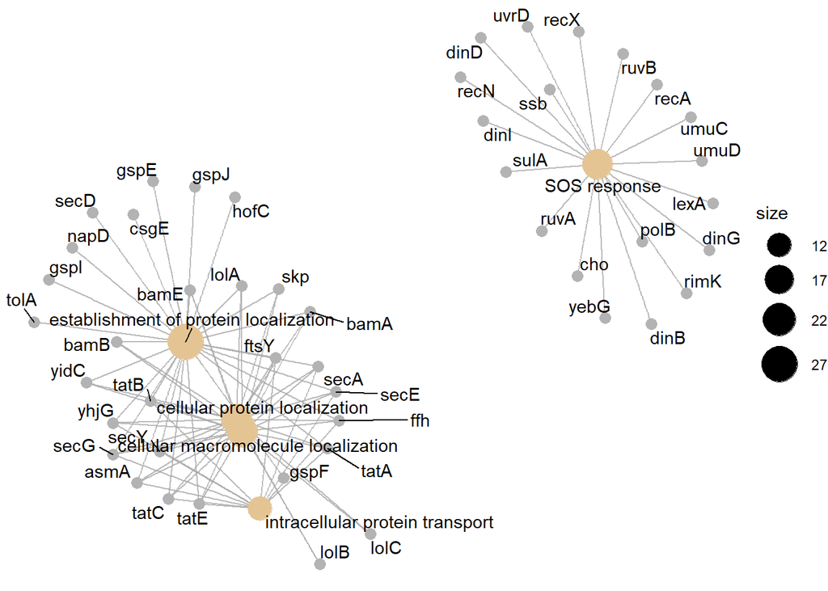

```r
cnetplot(enrich.result, categorySize = "geneNum", schowCategory = 15,
  vertex.label.cex = 0.75)
```